# Supplemental Materials for: *To accept or reject heterospecific mates*

## Figure 1

Figure 1 shows how the optimal acceptance threshold (along the x-axis) shifts with the relative fitness consequence of accepting a heterospecific mate (i.e., producing hybrid offspring) vs. accepting a conspecific mate.

*Note that here and throughout, we use “*V*” in place of parameter* F* and “*v*” in place of parameter *f* because “F” means FALSE in R.

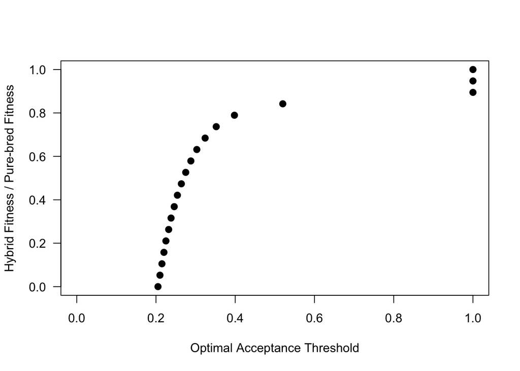

```r
# set up we will plot 20 points
times = 20
best.t = vector(length = times)



# constant parameter values. 'V' stands in for 'F' in main text because 'F'
# means FALSE in R.
V = 10
P = 0.7
Cs = 1
# now, we vary the fitness consequence of accepting heterospecific mates (f,
# represented here by v), ranging from 0 (hybrids are inviable) to V (there
# is no fitness reduction for accepting heterospecific mates)
v = seq(0, V, length = times)

# now, calculate fitness for each threshold given a specific value of f, and
# estimate what threshold value gives the optimal fitness.
for (i in 1:times) {
    Wt = (V * P * Gt.value + v[i] * (1 - P) * Bt.value - Cs)/(P * Gt.value +
        (1 - P) * Bt.value)
    best.t[i] = t[which.max(Wt)]
}

# generate plot
plot(best.t, v/V, type = "p", xlim = c(0, 1), lwd = 2, las = 1, pch = 19, xlab = "Optimal Acceptance Threshold",
    ylab = "Hybrid Fitness / Pure-bred Fitness")
```

## Figure 2

Figure 2 shows how the rates of acceptance error can vary based on search costs or skews in abundance of conspecifics and heterospecifics. Here, we use parameter values that match Reeve (1989) Figure 5.

```r
g = function(x) dnorm(x, mean = 0, sd = 0.1)  #conspecifics
b = function(x) dnorm(x, mean = 0.5, sd = 0.15)  #heterospecifics
t = seq(0, 1, length = 1001)  #set up 1000 possible thresholds between 0 and 1


Gt = list(0)
Bt = list(0)

for (i in t) Gt[[which(t == i)]] = integrate(g, lower = -1, upper = i)$value
Gt.value = unlist(Gt)

for (i in t) Bt[[which(t == i)]] = integrate(b, lower = -1, upper = i)$value
Bt.value = unlist(Bt)
```

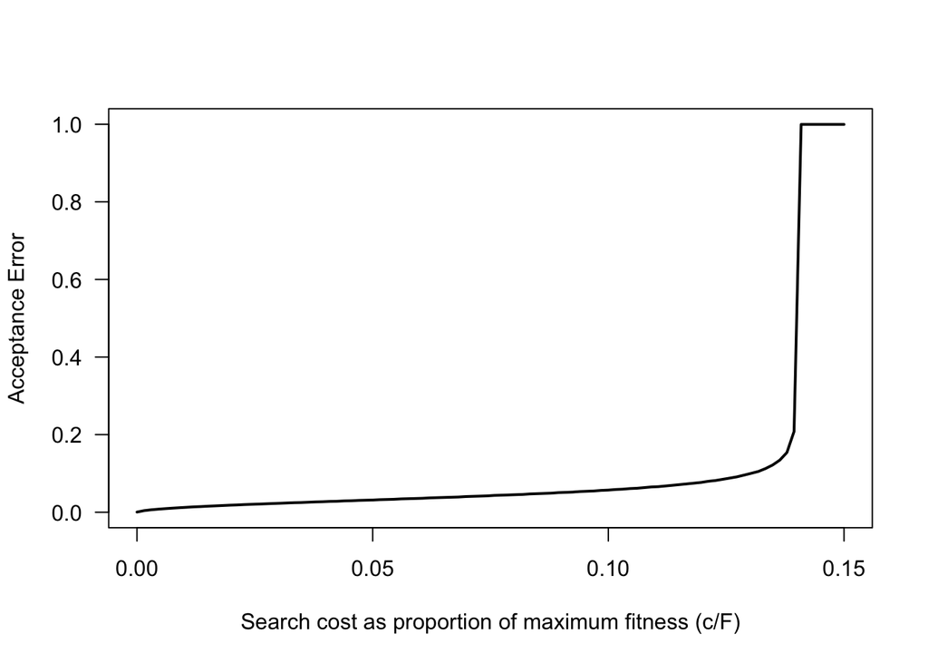

```r
# set up parameter values for Figure 2a
V = 10
v = 8
P = 0.7
# vary costs between 0 and 1.5 (i.e., 0 to 0.15 the fitness of mating with
# conspecific)
Cs = seq(0, 1.5, length = 100)

accept.error = vector(length = 100)  #set up vector

# acceptance error is proportion of heterospecifics accepted.
for (i in 1:100) {
    Wt = (V * P * Gt.value + v * (1 - P) * Bt.value - Cs[i])/(P * Gt.value +
        (1 - P) * Bt.value)
    accept.error[i] = Bt.value[which.max(Wt)]
}

plot(Cs/V, accept.error, xlim = c(0, 0.15), ylim = c(0, 1), type = "l", lwd = 2,
    ylab = "Acceptance Error", xlab = "Search cost as proportion of maximum fitness (c/F)",
    las = 1)
```

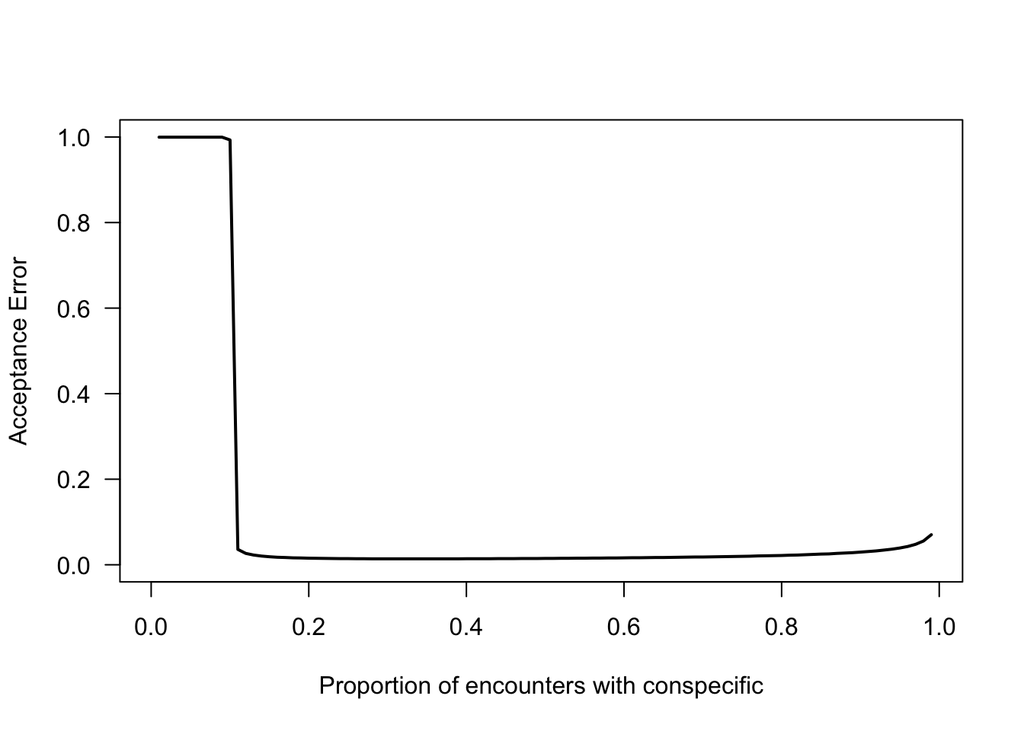

```r
## Figure 2b

V = 10
v = 8
Cs = 0.2
# vary proportion population that are conspecifics
P = seq(0.01, 0.99, 0.01)
accept.error = vector(length = length(P))

for (i in 1:length(P)) {
    Wt = (V * P[i] * Gt.value + v * (1 - P[i]) * Bt.value - Cs)/(P[i] * Gt.value +
        (1 - P[i]) * Bt.value)
    accept.error[i] = Bt.value[which.max(Wt)]
}

plot(P, accept.error, xlim = c(0, 0.99), ylim = c(0, 1), type = "l", ylab = "Acceptance Error",
    xlab = "Proportion of encounters with conspecific", las = 1, lwd = 2, main = "",
    xaxp = c(0, 1, 5))
```